# Projet Analyse De Donnée

Inzdine Semour & Franck Tadi Armel Nguemen

2024-04-03

**1 Introduction**

**Presentation des données**

On dispose de 68 observations pour lesquels ont été relevées dans 13 variables : 12 variables quantitatives dont Natal, Chomage, a.prim, a.sec, pib, fbcf, infl, recc, m.inf, prot, nrj, Année et une variables qualitatives Pays. Chaque ligne correspond aux distributions d’un Pays dans une Année différente. La variable Année sera traité comme une variable qualitative dans le sens où on a que les distributions d’effectifs de cette variable à 4 modalités qui represente l’année : 75, 77, 79 et 81. La catégorie de Pays, variable qualitative à 17 modalités : AL, AU, BE, CA, DA, ES, EU, FI, FR, IR, IT, JA, NO, PB, PO, RU et SU.

```r
knitr::kable(head(ocde))
```

| Pays | Natal | Chomage | a.prim | a.sec | pib | fbcf | infl | recc | m.inf | prot | nrj | Annee |
| --- | --- | --- | --- | --- | --- | --- | --- | --- | --- | --- | --- | --- |
| AL | 97 | 41 | 73 | 460 | 6870 | 211 | 60 | 409 | 197 | 58 | 394 | 75 |
| AL | 95 | 40 | 68 | 453 | 8410 | 209 | 48 | 435 | 155 | 65 | 425 | 77 |
| AL | 95 | 33 | 62 | 449 | 12450 | 227 | 41 | 427 | 147 | 67 | 463 | 79 |
| AL | 101 | 44 | 55 | 435 | 11076 | 220 | 47 | 446 | 126 | 68 | 427 | 81 |
| AU | 123 | 17 | 125 | 409 | 4990 | 267 | 78 | 391 | 205 | 56 | 307 | 75 |
| AU | 114 | 16 | 118 | 406 | 6380 | 272 | 69 | 430 | 168 | 58 | 330 | 77 |

**2.1 Analyse univariée**

L’analyse univariée constitue une première étape essentielle dans l’exploration de données, se concentrant sur l’examen et la compréhension d’une seule variable à la fois. Dans cette étude, nous mettons en œuvre des techniques telles que le résumé statistique et la visualisation des données pour analyser en profondeur les caractéristiques et la distribution de la variable étudiée.

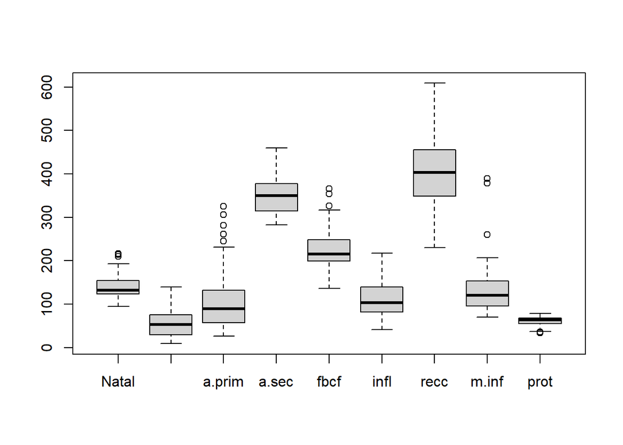

Le pourcentage d’actifs dans le secteur secondaire (a.sec) et le recettes courantes par habitant (recc) sont plus importantes que les largeurs. La variable prot a une faible variabilité (les Pays ont une consommation de protéines animales par habitant assez similaires) et la variable recc une assez forte variabilité (il y de l’hétérogénéité, soit entre les Pays aucours des années).

```
## Pays
## AL AU BE CA DA ES EU FI FR IR IT JA NO PB PO RU SU
##  4  4  4  4  4  4  4  4  4  4  4  4  4  4  4  4  4
```

Il y a 17 Pays et pour chaque pays on dispose 4 observations prisent sur différentes années.

```
##    Min. 1st Qu.  Median    Mean 3rd Qu.    Max.
##    1550    5230    7425    7574    9704   13937
```

```
##    Min. 1st Qu.  Median    Mean 3rd Qu.    Max.
##    88.0   304.5   392.5   425.0   496.5   927.0
```

Dans notre cas, l’IQR du PIB par habitant s’étend de 5230 à 9704 unités. Cela signifie que la moitié des pays ont un PIB par habitant compris entre 5230 et 9704 unités. Cette variation substantielle indique une grande disparité dans les niveaux de richesse entre les pays. Ce qui se confirme par le fait que le PIB minimum est de 1550 (Pays Po en l’an 1975) alors que le PIB maximum relevé est de 13937 (Pays No en l’an 1981).

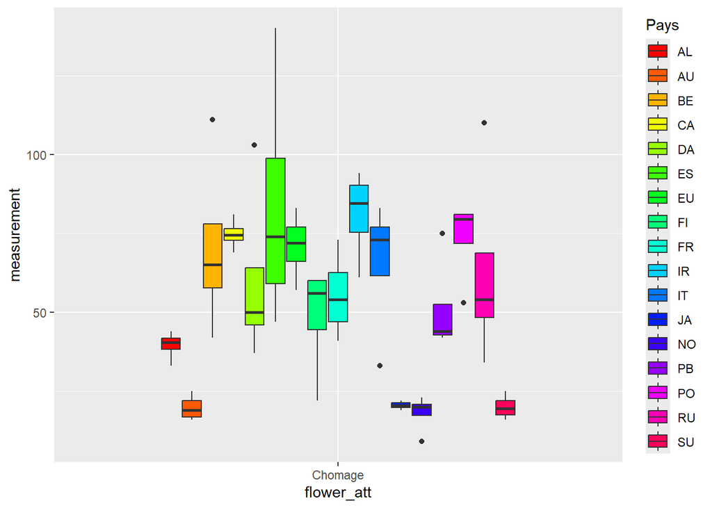

| Pays | Natal | Chomage | a.prim | a.sec | pib | fbcf | infl | recc | m.inf | prot | nrj | Annee |
| --- | --- | --- | --- | --- | --- | --- | --- | --- | --- | --- | --- | --- |
| AL | 97.00 | 39.50 | 64.50 | 449.25 | 9701.50 | 216.75 | 49.00 | 429.25 | 156.25 | 64.50 | 427.25 | 78 |
| AU | 119.00 | 19.75 | 113.00 | 405.00 | 7333.00 | 259.50 | 63.00 | 431.25 | 161.75 | 58.00 | 336.50 | 78 |
| BE | 124.25 | 70.75 | 32.75 | 366.75 | 8765.25 | 205.25 | 78.50 | 424.25 | 133.25 | 62.75 | 454.25 | 78 |
| CA | 153.75 | 74.75 | 57.50 | 288.50 | 9225.25 | 232.75 | 91.25 | 370.75 | 130.50 | 65.50 | 898.25 | 78 |
| DA | 121.25 | 60.00 | 86.50 | 303.00 | 10085.00 | 201.00 | 105.25 | 473.00 | 91.50 | 69.00 | 375.50 | 78 |
| ES | 167.50 | 83.75 | 200.50 | 368.75 | 4067.00 | 209.50 | 168.25 | 266.50 | 132.75 | 52.50 | 189.75 | 78 |
| EU | 154.00 | 71.00 | 36.75 | 298.50 | 9764.25 | 174.50 | 84.25 | 322.50 | 140.00 | 73.00 | 814.75 | 78 |
| FI | 136.25 | 48.50 | 126.75 | 350.25 | 7734.50 | 252.00 | 118.50 | 403.75 | 93.50 | 65.50 | 515.25 | 78 |
| FR | 143.00 | 55.50 | 95.75 | 369.25 | 8690.50 | 221.25 | 106.00 | 431.25 | 109.75 | 74.00 | 346.75 | 78 |
| IR | 213.75 | 81.00 | 212.50 | 310.25 | 3666.25 | 273.50 | 149.25 | 371.00 | 150.50 | 67.75 | 244.25 | 78 |

[output cut: 7 more lines]

**2.2 Analyse Bivariée**

L’analyse bivariée est une méthode statistique essentielle pour explorer les relations entre deux variables dans un ensemble de données. Le diagramme de dispersion offre une visualisation intuitive de la relation entre les variables, tandis que le coefficient de corrélation de Pearson fournit une mesure quantitative de la force et de la direction de la relation linéaire entre les variables. Cette approche nous permettra de mieux comprendre les associations entre les variables et d’identifier d’éventuelles tendances ou motifs dans nos données.

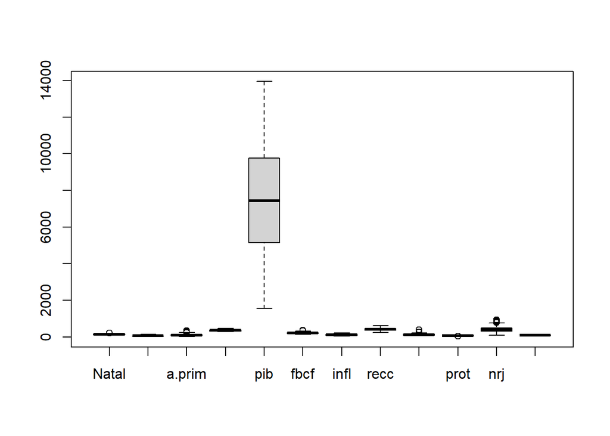

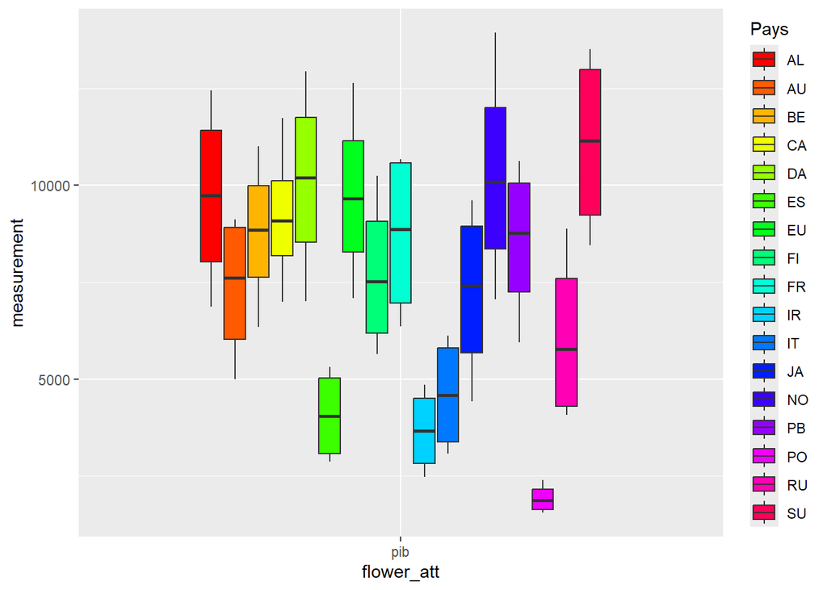

La plus grande différence entre les pays se fait au niveau du PIB par habitant.La variabilité de cette variable est très élevéecomparée aux autres variables. Ce qui serait interessant de voir la dispersion PIB par habitant selon le pays.

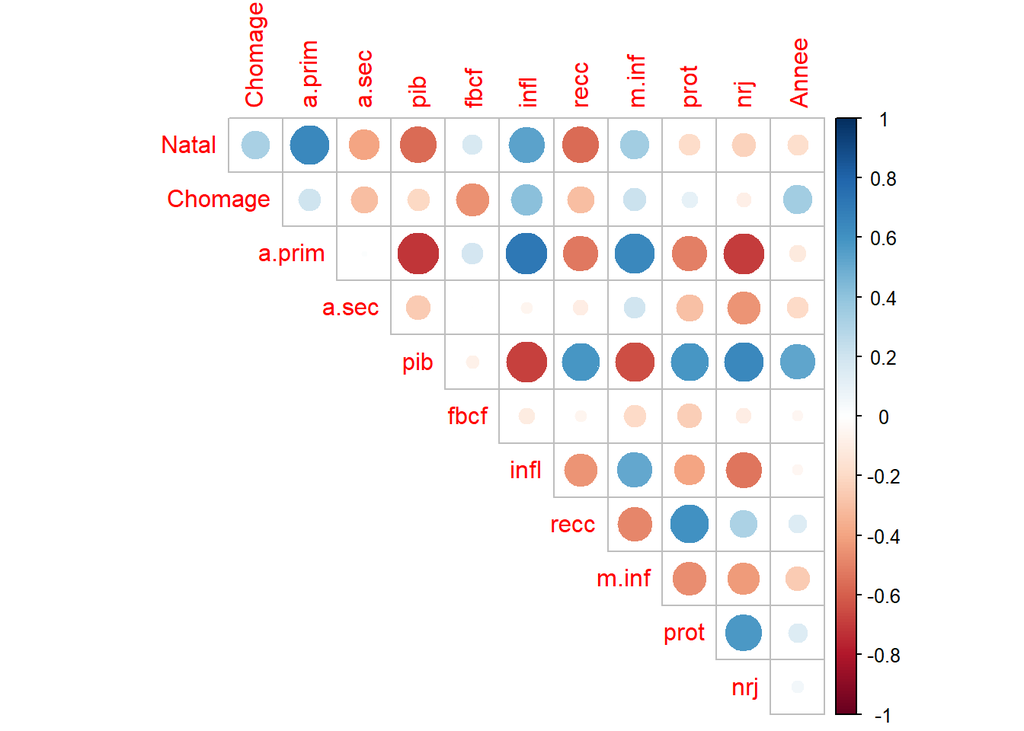

| Pays | mean_PIB |
| --- | --- |
| AL | 9701.50 |
| AU | 7333.00 |
| BE | 8765.25 |
| CA | 9225.25 |
| DA | 10085.00 |
| ES | 4067.00 |
| EU | 9764.25 |
| FI | 7734.50 |
| FR | 8690.50 |
| IR | 3666.25 |
| IT | 4590.75 |
| JA | 7211.50 |
| NO | 10289.25 |
| PB | 8527.75 |
| PO | 1922.00 |
| RU | 6124.00 |
| SU | 11066.25 |

[output not shown]

[output not shown]

**Lien entre les variables 2 à 2**

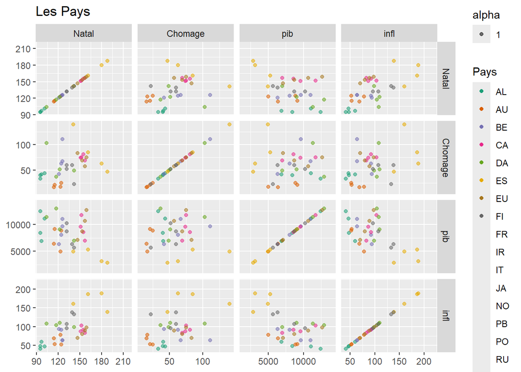

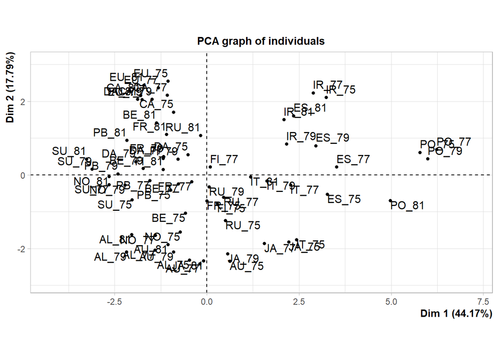

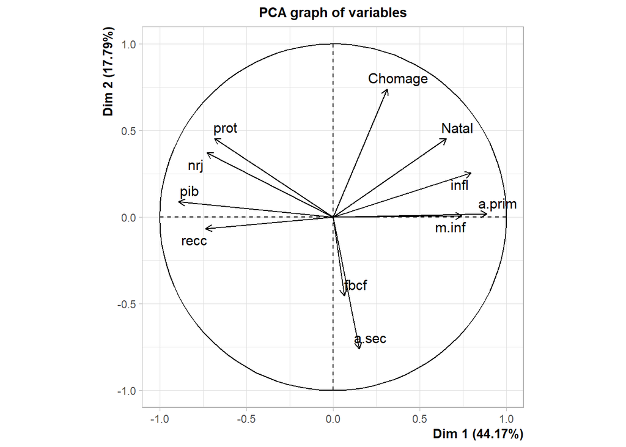

Dans le cadre de notre nouveau jeu de données où on a retiré la variable Pays et Annee afin de pouvoir distinguer facilement chaque pays dans l’année. Nous utilisons l’ACP comme outil d’analyse descriptive afin de mieux comprendre les relations entre les variables et les observations. L’ACP nous permettra d’observer les relations entre les variables à travers le cercle de corrélation, qui illustre la corrélation entre les variables et les composantes principales. De plus, nous examinerons le graphe des individus, qui nous permettra de visualiser la similarité ou la dissimilarité entre les observations dans l’espace des composantes principales.

**3.1 Cercles Des Corrélations**

|  | eigenvalue | percentage of variance | cumulative percentage of variance |
| --- | --- | --- | --- |
| comp 1 | 4.8583951 | 44.1672283 | 44.16723 |
| comp 2 | 1.9567562 | 17.7886924 | 61.95592 |
| comp 3 | 1.4026124 | 12.7510214 | 74.70694 |
| comp 4 | 0.7700245 | 7.0002229 | 81.70717 |
| comp 5 | 0.5684113 | 5.1673753 | 86.87454 |
| comp 6 | 0.4516432 | 4.1058477 | 90.98039 |
| comp 7 | 0.3335039 | 3.0318538 | 94.01224 |
| comp 8 | 0.2731346 | 2.4830422 | 96.49528 |
| comp 9 | 0.2257965 | 2.0526952 | 98.54798 |
| comp 10 | 0.0927308 | 0.8430071 | 99.39099 |
| comp 11 | 0.0669915 | 0.6090137 | 100.00000 |

Le critère de Kaiser suggère de conserver uniquement les axes dont les valeurs propres sont supérieures à 1, car ils captent plus de variance que ce qui pourrait être expliqué par le hasard.Par conséquent, nous devrions conserver les 3 premiers axes pour notre analyse, car ils expliquent chacun une part significative de la variance des données. Il faudra vérifier la bonne représentativité des variables d’origine sur le plan principal afin de voir si on ne considère pas plus de 2 axes.

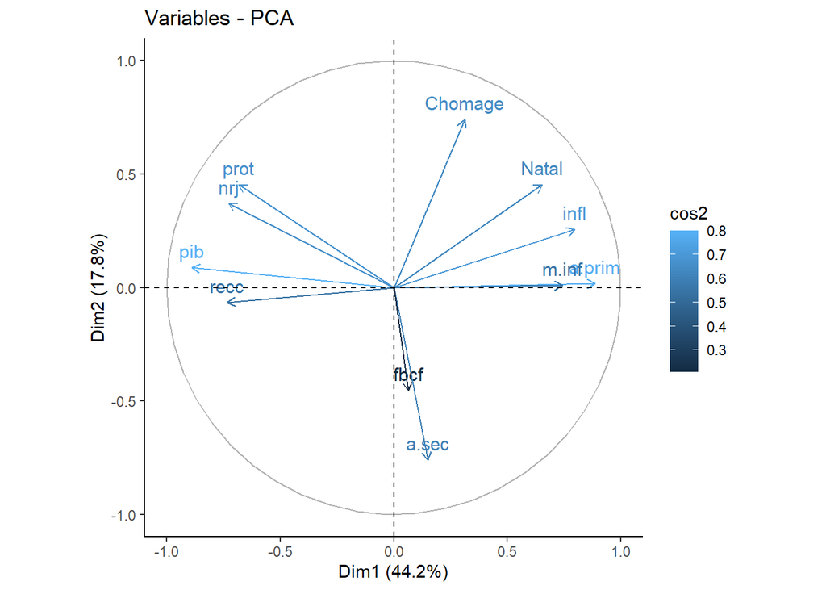

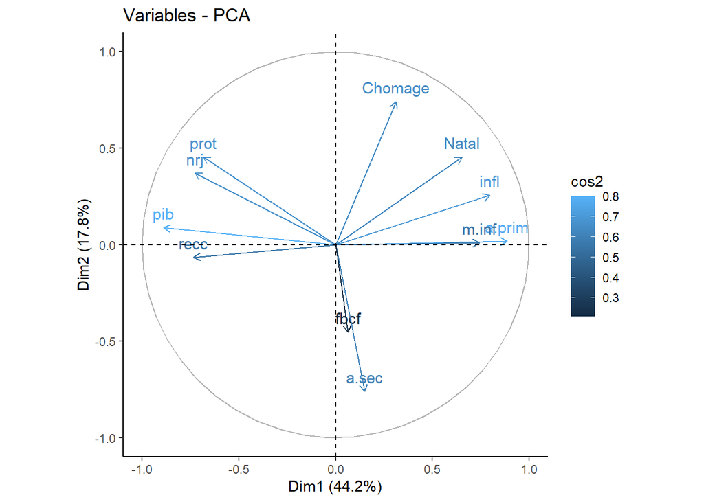

**3.2 Graphe Des Individus**

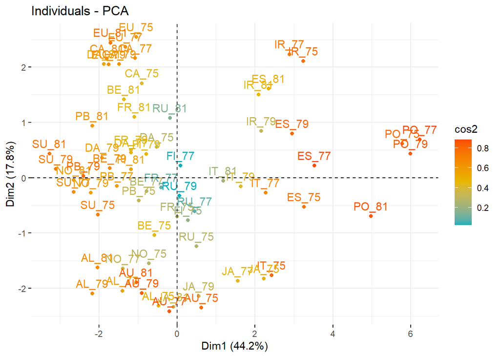

Il semble que la RU, FI, et FR sont très mal représentés sur ce plan. On ne les interprétera pas.

|  | x |
| --- | --- |
| RU_79 | 0.0253678 |
| FI_77 | 0.0273959 |
| RU_77 | 0.0816508 |
| FR_77 | 0.0942750 |
| RU_81 | 0.1412258 |
| FI_75 | 0.1930423 |

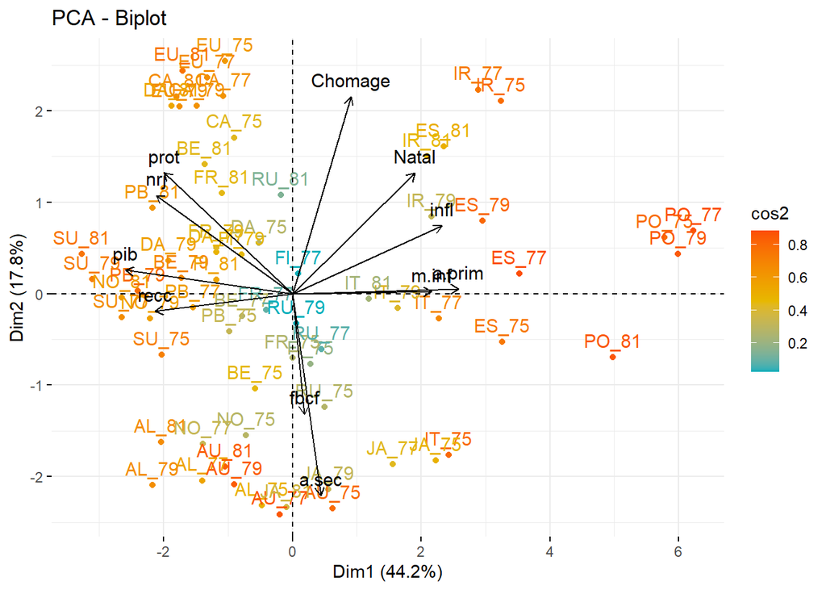

**3.3 Classification non supervisée**

**Effectuer une classification par la méthode CAH**

Cette methode vise à regrouper des individus similaires en groupe homogènes, en se basant sur les similitudes ou les dissimilarités entre eux. L’outil qu’on utilise pour visualiser les résultats de la CAH est le dendrogramme, un diagramme arborescent qui illustre les regroupements hiérarchiques des individus ou des variables en fonction de leur proximité. En scrutant le dendrogramme, nous pouvons identifier les regroupements naturels au sein de nos données, ainsi que les niveaux de similarité entre les différents groupes. Cette approche facilite la détection de structures sous-jacentes, offrant ainsi des perspectives précieuses pour l’interprétation des résultats et la prise de décision.

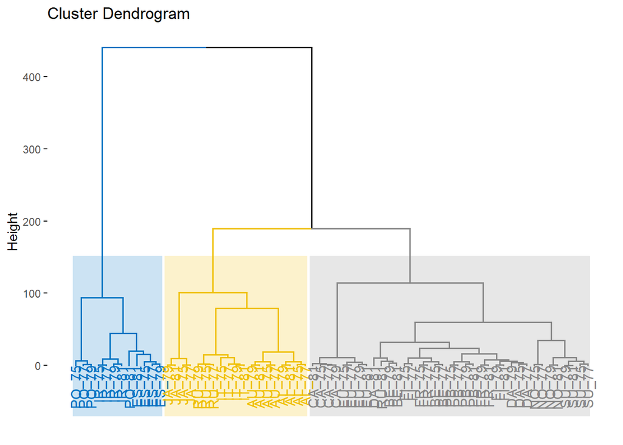

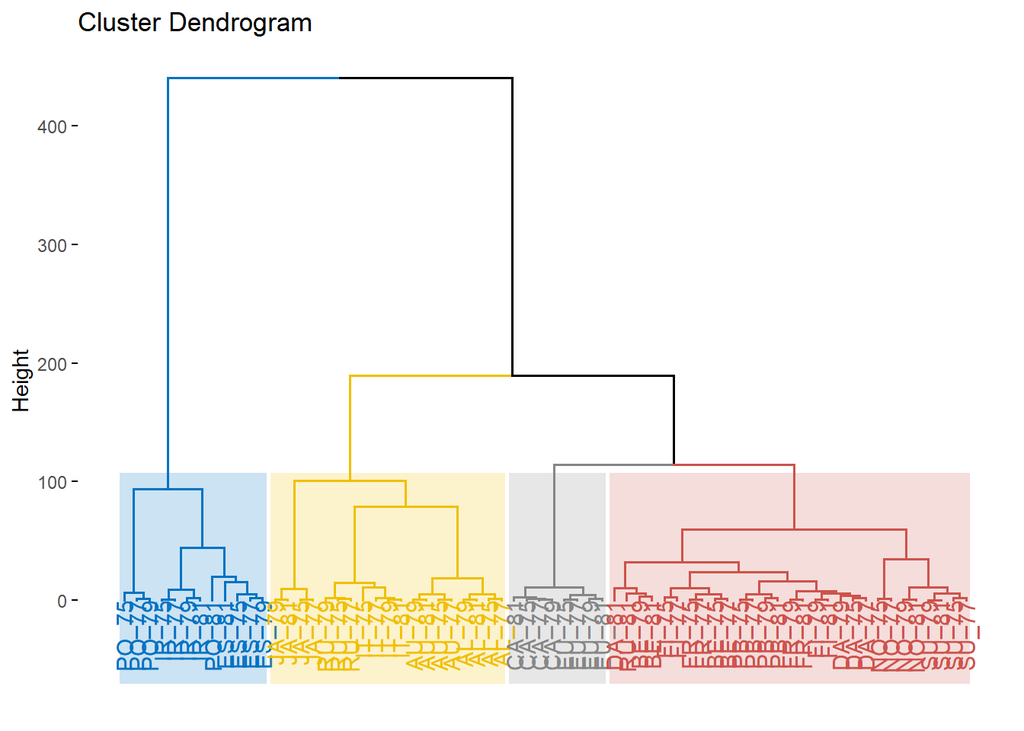

En choisissant les coupures judicieusement, nous pouvons identifier 3 à 4 groupes homogènes qui capturent efficacement la structure des données tout en évitant une fragmentation excessive ou une agrégation excessive.

**Caractérisation des groupes**

**• Représentation des groupes sur le plan principal de l’ACP**

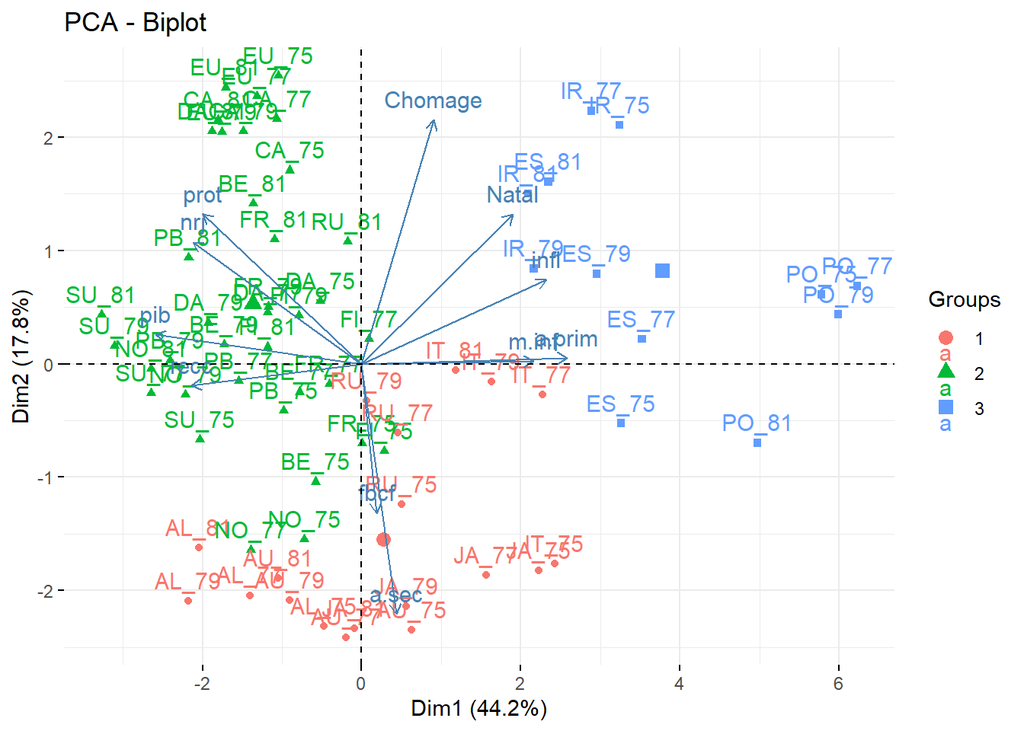

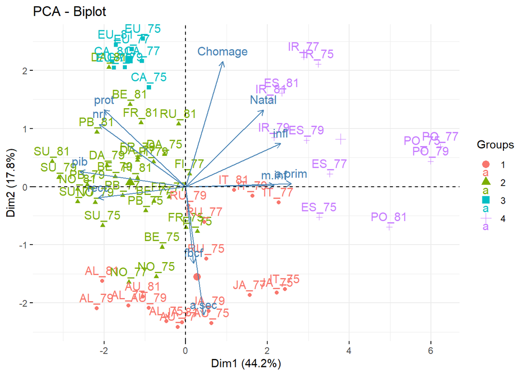

• Moyennes des différentes variables par groupe

| Group.1 | Chomage | a.prim | a.sec | pib | fbcf | infl | recc | m.inf | prot | nrj |
| --- | --- | --- | --- | --- | --- | --- | --- | --- | --- | --- |
| 1 | 48.4 | 79.6 | 353.4 | 8507.8 | 226.8 | 96.2 | 424.9 | 119.5 | 62.1 | 478.0 |
| 2 | 79.3 | 235.5 | 341.5 | 3218.4 | 232.0 | 172.1 | 302.2 | 212.5 | 53.0 | 177.8 |

Pour la classification en 2 groupes, les 2 groupes se distinguent par leur PIB et nrj (élevé ou faible). Leur a.sec est assez similaire.

| Group.1 | Chomage | a.prim | a.sec | pib | fbcf | infl | recc | m.inf | prot | nrj |
| --- | --- | --- | --- | --- | --- | --- | --- | --- | --- | --- |
| 1 | 38.1 | 97.2 | 400.5 | 6892.5 | 236.7 | 99.3 | 374.3 | 143.4 | 52.9 | 336.8 |
| 2 | 53.8 | 70.6 | 329.2 | 9337.2 | 221.7 | 94.6 | 450.9 | 107.2 | 66.8 | 550.4 |
| 3 | 79.3 | 235.5 | 341.5 | 3218.4 | 232.0 | 172.1 | 302.2 | 212.5 | 53.0 | 177.8 |

| Group.1 | Chomage | a.prim | a.sec | pib | fbcf | infl | recc | m.inf | prot | nrj |
| --- | --- | --- | --- | --- | --- | --- | --- | --- | --- | --- |
| 1 | 42.7 | 92.6 | 413.0 | 6807.4 | 217.5 | 102.7 | 407.1 | 158.9 | 57.5 | 344.1 |
| 2 | 48.5 | 77.1 | 339.1 | 9293.8 | 226.7 | 96.4 | 479.7 | 99.4 | 66.2 | 466.0 |
| 3 | 72.9 | 47.1 | 293.5 | 9494.8 | 203.6 | 87.8 | 346.6 | 135.2 | 69.2 | 856.5 |
| 4 | 82.2 | 212.6 | 342.3 | 3703.4 | 249.4 | 164.4 | 314.6 | 154.8 | 57.8 | 204.6 |
| 5 | 20.5 | 114.5 | 353.5 | 7211.5 | 308.5 | 86.5 | 251.2 | 85.0 | 35.5 | 309.8 |
| 6 | 70.7 | 304.3 | 339.0 | 1763.3 | 179.7 | 195.0 | 265.3 | 385.7 | 38.7 | 97.7 |